# Testing significance of different variables with *functClust*

Benoît Jaillard

2020-11-30

## Are all components or observations equally important?

Functional clustering thus leads to ask the following questions: are some components that belong to each functional group more efficient than others? How can component efficiency be assessed? Is it possible to priorize components for their effect on system performance? Similar questions can be raised about relative importance of different observations, that is different observed component assemblages of the collection, or of different observed performances in the case of repeated observations of the performance, or the observations of different properties carried out by the interactive system.

The function *ftest* answer to the questions. The method is based on removing one element of the dataset and evaluating the perturbation induced on functional clustering. The removed element can be a system component, a component assemblage, or an assemblage performance. The induced perturbation is evaluated by comparing the clustering tree obtained with removing the element, to the reference clustering tree obtained with the complete dataset. Different indices are computed, using the R-package **clusterCrit** (Package “clusterCrit”: Clustering Indices, by Bernard Desgraupes, University of Paris Ouest - Lab Modal’X). The indices are: *Precision* index and *Recall* index, or indices proposed by different authors as *Czekanowski_Dice* index, *Folkes_Mallows* index, *Jaccard* index, *Kulczynski* index, *Rogers_Tanimoto* index, *Russel_Rao* index, and both *Sokal_Sneath1* and *Sokal_Sneath2* indices.

## The function *ftest* and its options

The function *ftest* needs first that the function *fclust* is run for computing the reference clustering tree obtained with the complete dataset. The object returned by *fclust* is noted *fres*. The options of *ftest* are:

- **opt.var** determines the variable to treat. The option can be **“components”**, **“assemblages”** or **“performances”**.
- **opt.nbMax** determines the tree level to be reached. The function *ftest* is very time-consuming since it is based on the repeat of functional clusterings. Then, only the validated lowest part of the tree is interesting, from trunk (*tree-level = 1*) until the optimum level *fres$nbOpt*. Beyond the optimum level *fres$nbOpt*, the clustering does not bring any supplementary information. The computation therefore deserves to be stopped at this tree level. In *ftest*, the option *opt.nbMax = fres$nbOpt* by default. The option *opt.nbMax* allows the user to change the stop tree-level, more or less.
- **opt.R2** determines if the user needs to compute other statistiques than clustering indices. If *opt.R2 = TRUE*, each primary tree is validated and the vectors of coefficient of determination *R2* and efficiency *E* are computed.
- **opt.plot** determines if the user wish to follow the computation by plotting the resulting tree at each element removing. If option *opt.plot = TRUE*, the resulting tree is plotted at each element removing. The removed element is indicated on the tree plot.

The function *ftest* returns an object *rtest*, which consists on a list of matrices, each matrix containing the results for a given clustering index, and *R2* and *E* if *opt.R2* was checked.

## The function *ftest_plot*

The function *ftest_plot* first needs the object *fres* generated by the function *fclust*, and the object *rtest* generated by the function *ftest*. The options of *ftest_plot* are:

- **opt.crit** determines the indices to be plotted. The option *opt.crit* is a list or a vector of characters choisen among **“Czekanowski_Dice”**, **“Folkes_Mallows”**, **“Jaccard”**, **“Kulczynski”**, **“Precision”**, **“Rand”**, **“Recall”**, **“Rogers_Tanimoto”**, **“Russel_Rao”**, **“Sokal_Sneath1”** and **“Sokal_Sneath2”**.
- **opt.var** determines the variable to plot. The option can be **“components”**, **“assemblages”** or **“performances”**.

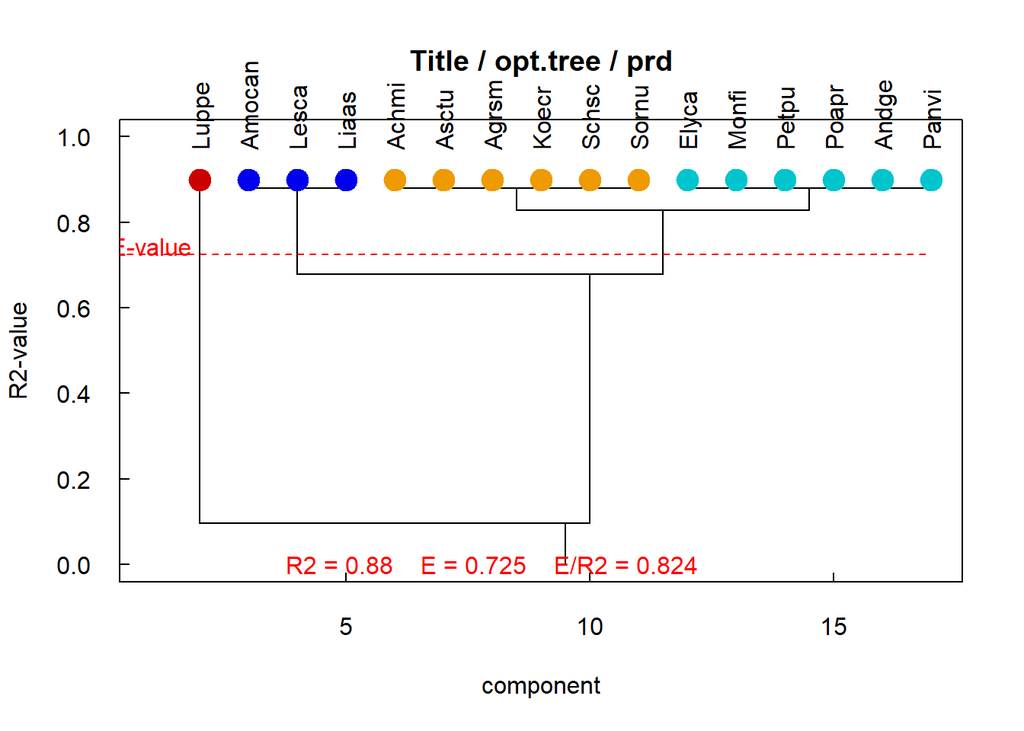

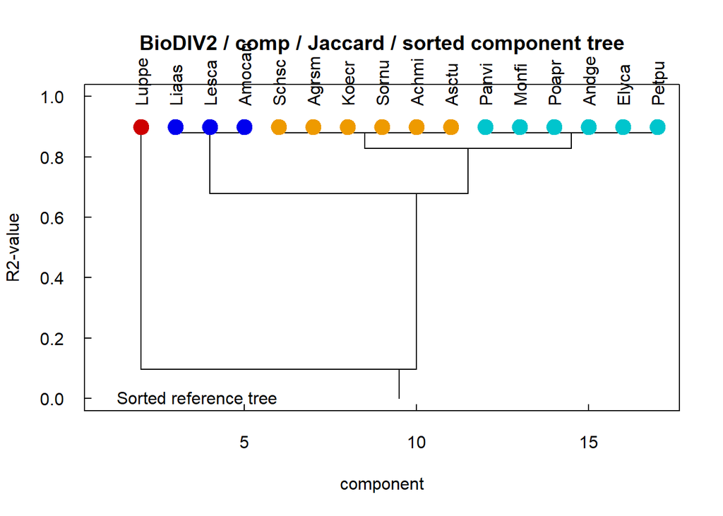

Raw tree on left, Tree with components sorted by decreasing effect on right

```r
fclust_plot(fres = CedarCreek.2004.2006.res, opt.tree = "prd")

ftest_plot(fres = CedarCreek.2004.2006.res,
           rtest = CedarCreek.2004.2006.test.components,
           main = "BioDIV2",
           opt.var = "comp", opt.crit = "Jaccard", opt.comp = "sorted.tree")
```

The graph on the left is the raw tree, directly obtained with the function *fclust*. On the right, the components of the tree are sorted by their decreasing effect of *Jaccard* index when they are one by one removed from dataset. For instance, within the component cluster *“b”* (in blue), the effect induced by species on ecosystem biomass can be sorted as: *“Liass”* > *“Lesca”* > *“Amocan”*.

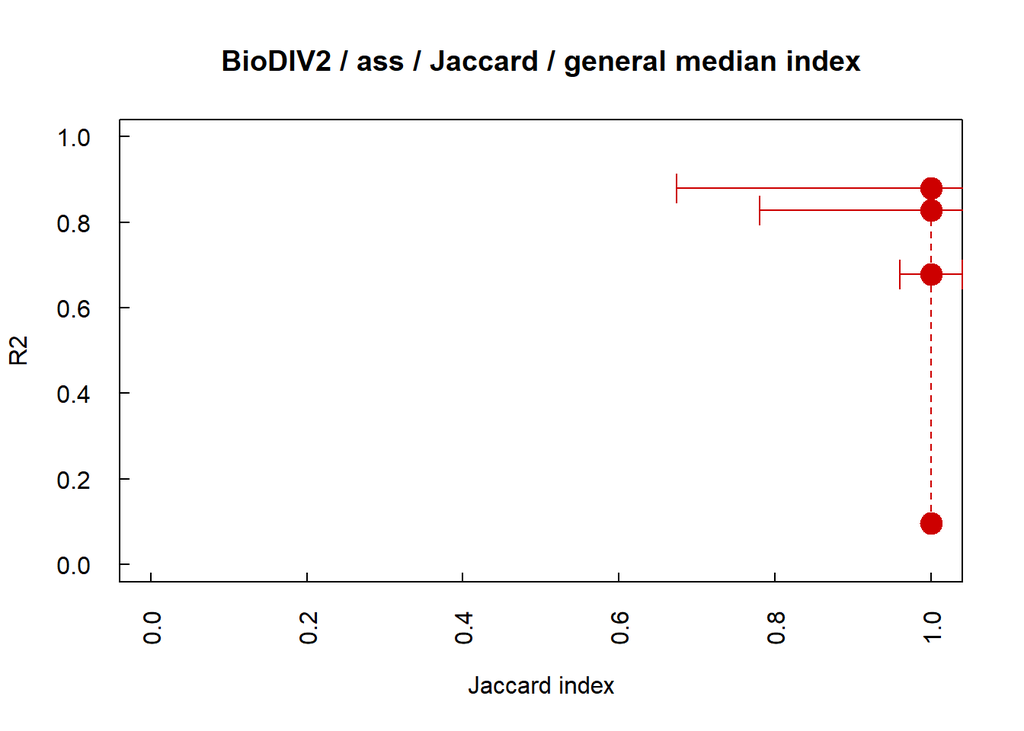

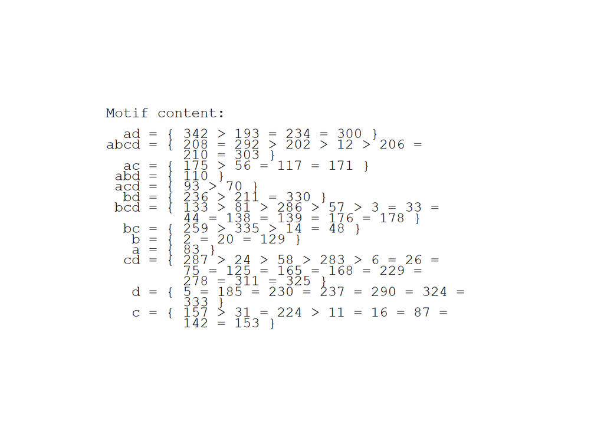

```r
ftest_plot(fres = CedarCreek.2004.2006.res,
           rtest = CedarCreek.2004.2006.test.assemblages,
           main = "BioDIV2", opt.var = "assemblages")
```

## The functions *ftest_write* and *ftest_read*

The functions **ftest_write** and **ftest_read** allow to save and load, respectively, the results generated by the function *ftest*.

## Note

Note that some computations are time-consuming. To facilitate the monitoring of the smooth running of the computations, informations are written on the Console and graphs are drawn on the Plots panel. The writting are enable or disable by the “verbose” option.

```r
getOption("verbose")
```

```
#> [1] FALSE
```

```r
# to follow the computations
options(verbose = TRUE)
# to deactivate the option
options(verbose = FALSE)
```